# Plankton Challenge

Arnaud Barral

Alice Dumay

Jeanne Barthélemy

Maxime Bouthors

# Foreword

There are two main datasets in this challenge:

- The image dataset
- The "features_native" dataset that corresponds to a handcrafted feature extraction of the previous dataset

We decided to focus on the image dataset with a deep learning approach, but also work on the other one just to have an idea of the performance we can achieve with the deep learning approach. That is why our work on "features_native" is minimalistic, even though it gives better results in the end.

We first present "features_native" results in order to directly have a comparative value for the next part.

# Features_native.csv

## Data exploration

```python
features_native = pd.read_csv("features_native.csv")
meta = pd.read_csv("meta.csv")
```

There are 65 features and all are numerical ones (either float64 or int64) and 243,610 entries.

There is no description as for what the features really are.

```python
nan_count = features_native.isna().sum()
print("NaN values count")
print(nan_count[nan_count.index[np.array(nan_count).nonzero()]])
```

```
NaN values count
perimareaexc      34428
feretareaexc      34428
cdexc             34428
convarea_area      6854
symetrieh_area     6854
symetriev_area     6854
nb1_area           6854
nb2_area           6854
nb3_area           6854
skeleton_area      6854
dtype: int64
```

## Data preprocessing

There are also missing values. As we have specific informations about them, we simply chose to replace them with the average value of the corresponding feature, instead of dropping them.

At the same we also add the labels by ordinally encoding them.

```python
data = features_native
data.loc[:, "level2"] = meta.loc[:, "level2"]
data_clean = data.dropna(subset=['level2'])


L = ["perimareaexc","feretareaexc","cdexc","convarea_area","symetrieh_area",
     "symetriev_area","nb1_area","nb2_area","nb3_area","skeleton_area"]

for features in L:
    data_clean.loc[:, features] = data_clean.loc[:, features].fillna((data_clean[features].mean()))

classes = data_clean['level2'].unique()
num_classes = len(classes)
classes_ids = {k: v for v, k in enumerate(classes)}
print(classes_ids)
print("Number of classes: "+str(num_classes))
```

```
{'detritus': 0, 'Rhizosolenids': 1, 'silks': 2, 'feces': 3, 'Codonaria': 4, 'Asterionellopsis': 5, 'Codonellopsis (Dictyocystidae)': 6, 'Dictyocysta': 7, 'Neoceratium': 8, 'Copepoda': 9, 'Coscinodiscids': 10, 'nauplii (Crustacea)': 11, 'Protoperidinium': 12, 'Annelida': 13, 'Ceratocorys horrida': 14…
Number of classes: 39
```

We split our data into features and labels:

```python
X = data_clean.drop(["objid","level2"], axis=1)

y_labels = np.array([classes_ids[level2] for level2 in data_clean.level2.values])
```

# Train/test split

Since some categories have few elements, we do not want the training data to have none of them (there is a probability that the testing set to contain all or most of the elements of such categories). If it were to happen it would not be possible to classify whole categories.

On the other way around, if all the elements are in the training set, the F1 accuracy measure would be biased toward an overestimation of success.

To avoid this, we chose to use a Stratified Shuffle Split that ensures that the data will be evenly split between the training, validation and testing sets.

```python
sss = StratifiedShuffleSplit(n_splits=1, train_size=0.5, random_state=0)
train_index, test_index = next(sss.split(X, y_labels))
X_train, X_test = X.to_numpy()[train_index], X.to_numpy()[test_index]
y_train, y_test = y_labels[train_index], y_labels[test_index]
```

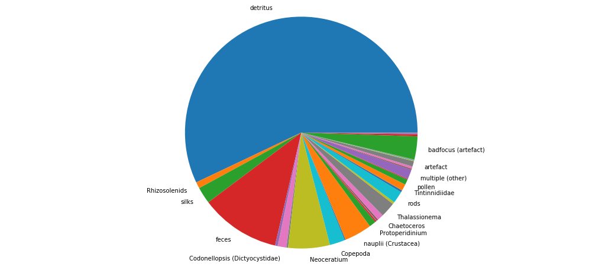

```python
plt.figure(figsize = (18,8))
counts = np.unique(np.array(y_train), return_counts=True)[1]
plt.pie(counts, labels=list(map(lambda k: k if counts[classes_ids[k]] > 700 else "", classes_ids.keys())),
           autopct=None)

plt.axis("equal")
plt.show()
```

**Observation**

We notice that almsot 70% are either detritus or feces which are not what we are really interested in: plaktons. Furthermore, the data is very imbalanced. Many categories have only few exemples.

## Data Normalization

Since we will use a logistic regression, we need to normalize the data. We will use the PowerTransformer of scikit-learn to do so. We chose this one because it does not suffer from outliers compared to other ones such as MinMaxScaler.

However we will not use it for the random forest since it is not necessary and in practice it can produce worse results.

```python
pt = PowerTransformer()
pt.fit(X_train)
X_train_normalized = pt.transform(X_train)
```

## Model Selection

We chose two models, a logistic regression a simple one that we will use as a reference, and a more complex one a random forest. We only chose 2 because we wanted to focus on the image classification part.

### Logistic regression

We used a gride search cross validation to directly optimize the parameters.

```python
parameters = {
    "penalty":['l2'],
    "tol": np.linspace(10**-5, 10**-3, 3),
    "C": np.linspace(1, 2, 3),
    "solver": ["sag", "saga"]
    }

grid_search = GridSearchCV(model, parameters, verbose = 1, n_jobs=6, cv=5)

grid_search.fit(X_train_normalized, y_train)
print(grid_search.best_score_)
print(grid_search.best_params_)
```

```
Fitting 5 folds for each of 18 candidates, totalling 90 fits
```

```
[Parallel(n_jobs=6)]: Using backend LokyBackend with 6 concurrent workers.
[Parallel(n_jobs=6)]: Done  38 tasks      | elapsed: 18.7min
[Parallel(n_jobs=6)]: Done  90 out of  90 | elapsed: 45.6min finished
```

```
0.7804090164007418
{'C': 2.0, 'penalty': 'l2', 'solver': 'sag', 'tol': 1e-05}
```

We chose "saga" and "sag" for the gride search since they are more appropriate for big dataset. It does not seem that the choice of the others parameters is very important for the logistic regression here. In fact the difference of performance is not that big. Nevertheless, the most important parameter here seems to be the number of iterations, we will set it to 500. We saw significative improvements by raising it from 100 to 500 whereas increasing it over 500 does not seem to produce significative improvements. Of course the bigger the number of iterations is, the greater the performance is.

```python
bestModel = LogisticRegression(penalty = "l2",
                               tol= 10**-5,
                               C = 2,
                               solver="sag",
                               max_iter= 500)

bestModel.fit(X_train_normalized, y_train)
```

```
LogisticRegression(C=2, class_weight=None, dual=False, fit_intercept=True,
                   intercept_scaling=1, l1_ratio=None, max_iter=500,
                   multi_class='auto', n_jobs=None, penalty='l2',
                   random_state=None, solver='sag', tol=1e-05, verbose=0,
                   warm_start=False)
```

### Random Forest

We also used a gride search to directly optimize the parameters of the random forest. The tunning process was quite long (more than 4 hours), we did not try to optimize it further than this.

```python
parameters = {
    "n_estimators":[50],
    "min_samples_split": np.linspace(0.001, 0.005, 5),
    "min_samples_leaf": np.linspace(0.0005, 0.005, 5),
    "max_depth":[20, 15, 10],
    "max_features":["auto", "log2", "sqrt"],
    "criterion": ["gini",  "entropy"],
    }

grid_search = GridSearchCV(model, parameters, verbose = 1, n_jobs=-1, cv=5)

grid_search.fit(X_train, y_train)
print(grid_search.best_score_)
print(grid_search.best_params_)
```

```
Fitting 5 folds for each of 450 candidates, totalling 2250 fits
```

```
[Parallel(n_jobs=-1)]: Using backend LokyBackend with 12 concurrent workers.
[Parallel(n_jobs=-1)]: Done  26 tasks      | elapsed:  3.1min
[Parallel(n_jobs=-1)]: Done 176 tasks      | elapsed: 13.2min
[Parallel(n_jobs=-1)]: Done 426 tasks      | elapsed: 31.8min
[Parallel(n_jobs=-1)]: Done 776 tasks      | elapsed: 54.7min
[Parallel(n_jobs=-1)]: Done 1226 tasks      | elapsed: 95.6min
[Parallel(n_jobs=-1)]: Done 1776 tasks      | elapsed: 185.6min
[Parallel(n_jobs=-1)]: Done 2250 out of 2250 | elapsed: 264.6min finished
[Parallel(n_jobs=1)]: Using backend SequentialBackend with 1 concurrent workers.
```

```
0.7964753040577363
{'criterion': 'entropy', 'max_depth': 20, 'max_features': 'auto', 'min_samples_leaf': 0.0005, 'min_samples_split': 0.001, 'n_estimators': 50}
```

```
[Parallel(n_jobs=1)]: Done  50 out of  50 | elapsed:  1.5min finished
```

```python
bestModel = RandomForestClassifier(n_estimators=50,
                                     min_samples_split=0.001,
                                     min_samples_leaf=0.0005,
                                     max_depth=20,
                                     max_features="auto",
                                     criterion="entropy")
bestModel.fit(X_train, y_train)
```

```
RandomForestClassifier(bootstrap=True, ccp_alpha=0.0, class_weight=None,
                       criterion='entropy', max_depth=20, max_features='auto',
                       max_leaf_nodes=None, max_samples=None,
                       min_impurity_decrease=0.0, min_impurity_split=None,
                       min_samples_leaf=0.0005, min_samples_split=0.001,
                       min_weight_fraction_leaf=0.0, n_estimators=50,
                       n_jobs=None, oob_score=False, random_state=None,
                       verbose=0, warm_start=False)
```

## Performance evaluation

#### Defining a measure of performance

We not only use the accuracy but also the F1 score that takes into account the false positive/negative predictions. Choosing `average=macro` favorises the prediction of small classes. It means that considering a plankton as a detritus is more penalizing than considering a detritus as a certain plankton. This is also related to our choice of a weighted categorical crossentropy biased toward small classes.

Futhermore in order to visually assess the model we also look at the confusion matrix.

### Logistic Regression

```python
from sklearn.metrics import f1_score

X_test_norm = pt.transform(X_test)

def accuracy(y, y_hat):
    return (y == y_hat).sum() / y.size

y_pred = bestModel.predict(X_test_norm)

print("weighted", f1_score(y_test, y_pred, average='weighted'))
print("macro", f1_score(y_test, y_pred, average='macro'))
print("accuracy", accuracy(y_pred, y_test))
```

```
weighted 0.7618385967398154
macro 0.3500366767925634
accuracy 0.7807491921123788
```

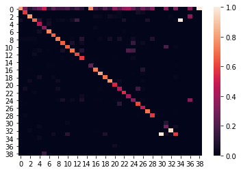

```python
cm = confusion_matrix(y_test, y_pred, normalize='pred')
sns.heatmap(cm)
```

### Random Forest

```python
from sklearn.metrics import f1_score


def accuracy(y, y_hat):
    return (y == y_hat).sum() / y.size

y_pred = bestModel.predict(X_test)

print("weighted", f1_score(y_test, y_pred, average='weighted'))
print("macro", f1_score(y_test, y_pred, average='macro'))
print("accuracy", accuracy(y_pred, y_test))
```

```
weighted 0.7643641276031193
macro 0.2696052169477377
accuracy 0.7957445756116863
```

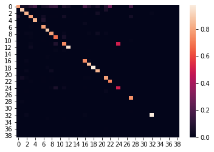

```python
cm = confusion_matrix(y_test, y_pred, normalize='pred')
sns.heatmap(cm)
```

#### Conclusion

At first we trough that the random forest was better. The cross validation accuracy during the gride search was better for the random forest (0.796) than for the logistic regression (0.780). But when we looked at the f1 macro score it was quite the opposite (respectively 0.270 and 0.350). The f1 macro score of the logistic regression is much greater than the one for the random forest.

Our hypothesis is that the random forest is optimizing the accuracy by favorizing the prediction of bigger classes of the dataset, and forgetting the small ones. This seems not to be the case for the logistic regression.

We can see it clearly when looking at the confusion matrices, the diagonal of the random forest one is brighter but has much more holes compared to the logistic regression one, where the diagonal is more "complete" and less bright.

# Image dataset

We used the *extract_zip_to_memory* to store the image ids in memory.

```python
def extract_zip_to_memory(input_zip):
    '''
    This function extracts the images stored inside the given zip file.
    It stores the result in a python dictionary.

    input_zip (string): path to the zip file

    returns (dict): {filename (string): image_file (bytes)}
    '''
    input_zip = zipfile.ZipFile(input_zip)
    return {name: BytesIO(input_zip.read(name)) for name in input_zip.namelist() if name.endswith('.jpg')}
```

```python
root_directory = '/mnt/datasets/plankton/flowcam/'
img_files = extract_zip_to_memory(root_directory + 'imgs.zip')
```

## Data visualization

```python
meta_data = pd.read_csv(root_directory + 'meta.csv')
```

- **Null values**: 0.4% of the level 2 values are NaN. We simply remove them.

```python
meta_data_cleaned = meta_data.dropna(subset=['level2'])
```

We use a dictionary to encode the categories associated to each name. The categories are ordinally encoded from 0 to 38.

```python
classes = meta_data_cleaned['level2'].unique()
num_classes = len(classes)
classes_ids = {k: v for v, k in enumerate(classes)}
print(classes_ids)
print("Number of classes: "+str(num_classes))
```

```
{'Ceratocorys horrida': 14, 'Annelida': 13, 'tempChaetoceros danicus': 37, 'Undellidae': 18, 'feces': 3, 'artefact': 27, 'Thalassionema': 17, 'Lithodesmioides': 36, 'Retaria': 23, 'detritus': 0, 'pollen': 22, 'chainlarge': 26, 'Asterionellopsis': 5, 'multiple (other)': 24, 'Pleurosigma': 28, 'Protop…
Number of classes: 39
```

Let's have a look at the dimensions of our images:

[output not shown]

The distribution of the height and width suggest that square resizing of shape 100x100 is relevant since it is roughly the average value of each distribution.

We notice that some images have shapes greater than 600, up to 1000 for the height. We will surely lose quality with a 100x100 resizing, but those images are neglectible with respect to the majority of images that have a shape $< 200$.

#### Image aspect

Note that the images have one channel (grayscale images), and it seems that all of them display elements on a white background. And the shape of the images perfectly intercept the elements we need to classify.

## Data loading

We will create these datasets referencing picture ids and they won't contains the images themselves.

```python
# creation of data ids and label values

X_ids = np.array(meta_data_cleaned.objid[:].apply(lambda x: str(x).split(".")[0]))
y_labels = np.array([classes_ids[level2] for level2 in meta_data_cleaned.level2.values])
```

#### Creation of train/validation/test sets

We also use the Stratified Shuffle Split here to evenly split the data.

```python
# Train/test split
sss = StratifiedShuffleSplit(n_splits=1, train_size=0.5, random_state=0)
train_index, test_index = next(sss.split(X_ids, y_labels))
X_train, X_test = X_ids[train_index], X_ids[test_index]
y_train, y_test = y_labels[train_index], y_labels[test_index]

# Create validation set
sss = StratifiedShuffleSplit(n_splits=1, train_size=0.75, random_state=0)
train_index, val_index = next(sss.split(X_train, y_train))
X_train, X_val = X_train[train_index], X_train[val_index]
y_train, y_val = y_train[train_index], y_train[val_index]
```

## Data generator

A bad idea would have been to use our previous functions to ceate the dataset of resized pictures of 100x100 pixels. However, it would have occupied too much space in memory.

We need to load our pictures "on the fly", in a more efficient way: we want real-time data feeding of our Keras model. For the data generator, we got inspired by this website : https://stanford.edu/~shervine/blog/keras-how-to-generate-data-on-the-fly

Since the images shapes are variable, we need a function to preprocess those images into a fixed shape of 100x100 so that we can feed our models. As the background of the images is white, to resize the images, we just fit the rectangular orginal image in a 100x100 square, and then fill the remaing area with white.

We have not found any implementation of such resizing preprocessing, so we implemented the function by ourselves.

```python
def resizeImage(img, w=100, l=100):
    w_, l_ = img.shape
    scale_factor = min(float(w)/float(w_), float(l)/float(l_))
    img = rescale(img, scale_factor, anti_aliasing=True, mode='reflect', multichannel=False)
    Dw, Dl = w - img.shape[0], l - img.shape[1]
    img = np.pad(img, ((int(np.ceil(Dw/2)), int(np.floor(Dw/2))),(int(np.ceil(Dl/2)), int(np.floor(Dl/2)))), mode='constant', constant_values=1.)
    return img

def accessImage(img_id, w=100, l=100): # Allows us to access the "resized" image
    img = np.array(Image.open(img_files['imgs/'+str(img_id)+'.jpg']))
    return resizeImage(img, w, l).reshape(w, l, 1)
```

By playing with the different shapes of resizing over a sample of images, we also notice that 100x100 is ideal to keep the details in most of the images. Here we can see the result of the resizing of an image:

```
(148, 65)
```

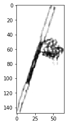

```
(100, 100)
```

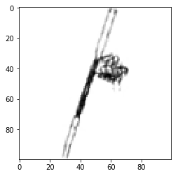

```python
img = np.array(Image.open(img_files['imgs/32758047.jpg']))
print(img.shape)
plt.imshow(img, cmap='gray')
plt.show()
img = resizeImage(img)
print(img.shape)
plt.imshow(img, cmap='gray')
plt.show()
```

```python
class DataGenerator(Sequence):
    'Generates data for Keras'
    def __init__(self, ids, labels, batch_size=32, dim=(100,100), n_channels=1,
                 n_classes=num_classes, shuffle=False, data_augmentation=False):
        'Initialization'
        self.dim = dim
        self.batch_size = batch_size
        self.labels = labels[:]
        self.list_IDs = ids[:]
        self.n_channels = n_channels
        self.n_classes = n_classes
        self.shuffle = shuffle
        self.on_epoch_end()
        self.data_augmentation = data_augmentation
        if self.data_augmentation:
            self.datagen = ImageDataGenerator(
                rotation_range=180,
                width_shift_range=0.1,
                height_shift_range=0.1,
                horizontal_flip=True,
                vertical_flip=True,
                fill_mode='nearest')

    def __len__(self):
        'Denotes the number of batches per epoch'
        return int(np.floor(len(self.list_IDs) / self.batch_size))

    def on_epoch_end(self):
        'Updates indexes after each epoch'
        # Assuming it preserves the correlation between labels and picture ids
        self.indexes = np.arange(len(self.list_IDs))
        if self.shuffle == True:
            np.random.shuffle(self.indexes)

    def __getitem__(self, index):
        'Generate one batch of data'
        # Generate indexes of the batch
        indexes = self.indexes[index*self.batch_size:(index+1)*self.batch_size]

        # Find list of IDs
        list_IDs_temp = [self.list_IDs[k] for k in indexes]

        # Generate data
        X, y = self.__data_generation(indexes, list_IDs_temp)

        return X, y

    def __data_generation(self, indexes, list_IDs_temp):
        'Generates data containing batch_size samples'
        # Initialization
        # X : (n_samples, *dim, n_channels)
        X = np.empty((len(indexes), *self.dim, self.n_channels))
        y = np.empty((len(indexes),1), dtype=int)

        if self.data_augmentation:
            X, y = next(self.datagen.flow(X, y, batch_size=self.batch_size, shuffle=False))

        # Generate data
        for i in range(len(indexes)):
            # Store sample
            ID = list_IDs_temp[i]
            X[i,] = accessImage(ID, self.dim[0], self.dim[1])
            # Store class
            y[i] = self.labels[indexes[i]]
        # return X, y
        return X, to_categorical(y, num_classes=self.n_classes)
```

**Initialisation**: We put as arguments relevant information about the data, such as dimension sizes, number of channels, number of classes, batch size, or decide whether we want to shuffle our data at generation. We also store important information such as labels and the list of IDs that we wish to generate at each pass.

**On epoch end**: Here, the method on_epoch_end is triggered once at the very beginning as well as at the end of each epoch. If the shuffle parameter is set to True, we will get a new order of exploration at each pass (or just keep a linear exploration scheme otherwise).

**len**: Each call requests a batch index between 0 and the total number of batches, where the latter is specified in the len method. A common practice to set this value is to ensure that the model sees the training samples at most once per epoch.

**getitem**: to generate the batch corresponding to a given index

> **Note**: If we choose `data_augmentation=True`, we use an ImageDataGenerator from keras that allows data augmentation. According to what we saw from those images, we enable flipping, shifting and rotation. But we found out that using data augmentation not only slowed down the execution, but produced slightly worse results. It may be caused by the `fill_mode` set to `nearest` that could produce artifacts in the augmented images. Or this is maybe due to 45° rotations that zoom out in the images, loosing details. Unfortunately, we have not had enough time to investigate this further.

## Model Selection

We setup the generators and general parameters.

```python
# Parameters
params = {'dim': (100, 100),
          'input_shape' :(100, 100, 1),
          'train_batch_size': 64,
          'val_batch_size': 32,
          'shuffle': True}

# Generators
training_generator = DataGenerator(ids=X_train, labels=y_train, batch_size=params['train_batch_size'], dim=params['dim'], n_channels=1,
                 n_classes=num_classes, shuffle=True, data_augmentation=True)
validation_generator = DataGenerator(ids=X_val, labels=y_val, batch_size=params['val_batch_size'], dim=params['dim'], n_channels=1,
                 n_classes=num_classes, shuffle=True)
```

We define a standard `train` function for all of our models.

> **Note**: We can configure the multiprocessing in the train function for faster executions (twice faster with 8 workers), but the latest version of tensorflow gave warnings that there could be deadlocks. That is what happened once while using data augmentation. Even though it was indicated to rather use efficient input pipelines using tf.data, we stuck to our implementation since it would have taken too much time to make it well.

```python
def train(model, epochs=6):
    #Keep track of the training time
    start = time.time()

    # Train model on dataset
    model.fit(training_generator,
              validation_data=validation_generator,
              epochs=epochs,
              use_multiprocessing=False,
              workers=1)

    end = time.time()
    hours, rem = divmod(end-start, 3600)
    minutes, seconds = divmod(rem, 60)
    print("Training time :")
    print("{:0>2}:{:0>2}:{:05.2f}".format(int(hours), int(minutes), seconds))
```

#### Defining the loss

We first used the already-built `categorical_crossentropy`, but it doesn't take into account the imbalanceness of the data. Since the planktons are in minority compared to detritus or feces, we do not want our model to only classify images as detritus/feces (that leads to around 65% accuracy). A way to incentive this is to use a weighted categorical crossentropy that penalizes more the wrong labelling of the less represented classes. We want a greater weight for smaller categories, but we do not want a too huge gap between the weights. That is why we use a logarithmic scale to calculate those weights:

$$w_k = \frac{1}{log(c_k) + \lambda}$$

where $c_k$ is the number of elements in class $k$, and $\lambda$ is a parameter we can tune: smaller $\lambda > 0$ leads to greater gaps (there is a max bound for this gap), and bigger $\lambda$ leads to a more uniform weighting.

We used **model 1** to tune this parameter and found out that a value very close to zero is better to maximize the F1 score we defined (see the paragraph dedicated to the measure of performance).

> **Note**: Keras has no implementation of weighted categorical cross entropy, so we implemented it by ourselves.

```python
unnomalized_weights = 1/(np.log(np.unique(np.array(y_labels), return_counts=True)[1].astype(np.float32)) + 0.01)
weights = tf.constant(unnomalized_weights/unnomalized_weights.sum())

def weighted_categorical_crossentropy(target, output, axis=-1):
    # scale preds so that the class probas of each sample sum to 1
    output = output / tf.math.reduce_sum(output, axis, True)
    # Compute cross entropy from probabilities.
    epsilon_ = tf.keras.backend.epsilon()
    output = tf.clip_by_value(output, epsilon_, 1. - epsilon_)
    return -tf.reduce_mean(tf.math.reduce_sum(weights * (target * tf.math.log(output) + (1 - target) * tf.math.log(1-output)), axis))
```

#### Defining the optimizer

We use the already built-in Adam optimizer that has been proven to be quite efficient by the litterature about optimization.

### Models

Since we are dealing with images, we found it relevant to use CNN models (Convolutional Neural Network).

###### Model 0

For a first model, we got inspired from **LeNet5** where a few convolutional layers with an increasing number of channel are alterned with MaxPooling layers to decrease the feature maps dimensionality. The final convolutional output before flattening is of shape (128, 2, 2) and the flattened version is directly connected to the output. To prevent vanishing/exploding gradient issues, we use the *relu* activation at each layer, except for the last one where we require an output between 0 and 1 for the loss calculation.

```python
model0 = Sequential()
model0.add(Conv2D(8, kernel_size=4, activation='relu', input_shape = params['input_shape']))
model0.add(MaxPooling2D(pool_size=(2, 2), strides=(2, 2), padding='valid'))
model0.add(Conv2D(16, kernel_size=3, activation='relu'))
model0.add(MaxPooling2D(pool_size=(2, 2), strides=(2, 2), padding='valid'))
model0.add(Conv2D(32, kernel_size=2, activation='relu'))
model0.add(MaxPooling2D(pool_size=(2, 2), strides=(2, 2), padding='valid'))
model0.add(Conv2D(64, kernel_size=2, activation='relu'))
model0.add(MaxPooling2D(pool_size=(2, 2), strides=(2, 2), padding='valid'))
model0.add(Conv2D(128, kernel_size=2, activation='relu'))
model0.add(MaxPooling2D(pool_size=(2, 2), strides=(2, 2), padding='valid'))
model0.add(Flatten())
model0.add(Dense(num_classes, activation='sigmoid'))

model0.compile(optimizer='adam', loss=weighted_categorical_crossentropy, metrics=['accuracy'])
```

$\rightarrow$ **Validation accuracy**: 69%

$\rightarrow$ **F1 macro score**: 14.7%

###### Model 1

**Model 1** is a variation of **Model 0** with one less convolutional layer, but with an extra fully-connected layer just after the flattening. The shape of the tensor just before the flattening is (64, 4, 4). We chose greater kernel sizes in general to reduce slightly more the feature maps dimensionality.

```python
model1 = Sequential()
model1.add(Conv2D(16, kernel_size=6, activation='relu', input_shape = params['input_shape']))
model1.add(MaxPooling2D(pool_size=(3, 3), strides=(3, 3), padding='valid'))
model1.add(Conv2D(24, kernel_size=5, activation='relu'))
model1.add(MaxPooling2D(pool_size=(2, 2), strides=(2, 2), padding='valid'))
model1.add(Conv2D(32, kernel_size=4, activation='relu'))
model1.add(MaxPooling2D(pool_size=(2, 2), strides=(2, 2), padding='valid'))
model1.add(Conv2D(64, kernel_size=2, activation='relu'))
model1.add(Flatten())
model1.add(Dense(100, activation='relu'))
model1.add(Dense(num_classes, activation='sigmoid'))

model1.compile(optimizer='adam', loss=weighted_categorical_crossentropy, metrics=['accuracy'])
```

$\rightarrow$ **Validation accuracy**: 76.9%

$\rightarrow$ **F1 macro score**: 38.8%

> **Note**: We obtained this result for $\lambda = 0.01$.

> With $\lambda = 1.0$, $F_1 = 38.1$%. With $\lambda = 10.0$, $F_1 = 37.3$%. That is why we stuck to $\lambda = 0.01$.

###### Model 2

**Model 2** has the exact same architecture than **model 1**, except that instead of using *relu* activation (that handles the exploding/vanishing gradient issue), we use batch normalization, that normalize the outputs of each convolutional layer, and *tanh*.

```python
model2 = Sequential()
model2.add(Conv2D(16, kernel_size=6, input_shape = params['input_shape']))
model2.add(BatchNormalization(momentum=0.8))
model2.add(Activation('tanh'))
model2.add(MaxPooling2D(pool_size=(3, 3), strides=(3, 3), padding='valid'))
model2.add(Conv2D(24, kernel_size=5))
model2.add(BatchNormalization(momentum=0.8))
model2.add(Activation('tanh'))
model2.add(MaxPooling2D(pool_size=(2, 2), strides=(2, 2), padding='valid'))
model2.add(Conv2D(32, kernel_size=4))
model2.add(BatchNormalization(momentum=0.8))
model2.add(Activation('tanh'))
model2.add(MaxPooling2D(pool_size=(2, 2), strides=(2, 2), padding='valid'))
model2.add(Conv2D(64, kernel_size=2))
model2.add(BatchNormalization(momentum=0.8))
model2.add(Activation('tanh'))
model2.add(Flatten())
model2.add(Dense(100, activation='relu'))
model2.add(Dense(num_classes, activation='sigmoid'))

model2.compile(optimizer='adam', loss=weighted_categorical_crossentropy, metrics=['accuracy'])
```

$\rightarrow$ **Validation accuracy**: 69.58%

$\rightarrow$ **F1 macro score**: 31.8%

###### backbone models

We tried to use pretrained backbone feature extractors from *keras.application* combined with fully-connected layers to see if they performed better than what we did so far.

We first encountered the problem of the image number of channels (that can be solved by converting our grayscale images to RGB format). Then we found out that the training of the fully-connected layers (by freezing the backbone) is way too slow (1 batch per second, and we have 1421 batches per epoch...). If we had more time, or Zoe executions of 6hrs+, we may have consider to further explore these backbone techniques.

### Performance evaluation

We make the predictions of our models on the testing data.

```python
testing_generator = DataGenerator(ids=X_test, labels=y_test, batch_size=32,
                                  dim=params['dim'], n_channels=1, n_classes=num_classes)
predictions = model1.predict(testing_generator, verbose=1, workers=8, use_multiprocessing=True)

y_pred = np.argmax(predictions, axis=1)
```

```python
cm = confusion_matrix(y_test[:len(y_pred)], y_pred, normalize='pred')
sns.heatmap(cm)
```

**Confusion matrix of *model 1* on testing data**:

[figure not shown]

The pies down here show the repartition of the categorization of the testing data. Whereas **Model 0** overestimates the proportion of detritus and of the other main categories, **Model 2** seems rather to hyper-compensate by diminishing drastically the proportion of detritus prediction.

**Model 1** on the other hand seems rather balanced, even though some classes are completely forgotten (the forgotten classes all contain less than 150 element in the whole data). This explains the higher F1 macro score of this model. But the fact these classes are forgotten highly decreases the F1 macro score, that is why we have such low values compared to the accuracy values.

[output not shown]

[output not shown]

# Conclusion

**Model 1** seems rather good, indeed it achieves the highest F1 macro score (*38.8%*), just followed by the logistic regression that achieves *35.0%*. This is difficult to say if we can possibly much more increase this score since the problem seems to come from the classes that are under-represented, and completely forgotten by all our models.

As the choice of logarithmic scaling for the weighting of the categorical crossentropy is arbitrary, maybe changing its formula could benefit, by increasing the weight of those forgotten classes. But on the other hand, we do not want the distribution of the classification differing too much from the orginal ones (see the pies). This problem is quite challenging and we have not had enough time to further explore it.

Nonetheless, eventhough the accuracy is a bit lower compared to the random forest, the F1 score indicates that **Model 1** is our best model so far. Maybe that upgrading this particular model with dropout, proper data augmentation or more complexity, while benefitting from the best possible weighted crossentropy, can overtake our current results. But as we said, we have not had enough time to completely perfect our models.